# Homework 09

The kernel-tuning question moved here from Homework 08. A solution for Question 1 will be available after Monday, October 26, 2026. No solution will be provided for Question 2.

## Question 1: Choosing an SVM kernel

Use `saheart.csv` from the combined ZIP. As in Homework 7, predict `chd` using the same nine predictors, coding `famhist` as 1 for `Absent` and 2 for `Present`.

Compare SVMs with a linear kernel, polynomial kernels of degrees 2 (quadratic), 3, and 4, and a radial basis kernel. Choose **no more than 20 candidate settings in total** across these kernels. Vary the cost $C$ for each kernel and the radial scale $\gamma$ for the radial kernel. State any other kernel settings you hold fixed.

Divide the observations into five folds yourself and use the same folds for all candidates. Standardize predictors using only the fitting observations in each fold. Report the candidate settings and their mean cross-validation misclassification rates. Which kernel and settings do you prefer? Give a brief justification.

**Answer 1.** I used the Homework 7 coding (`famhist` 1 = Absent, 2 = Present; the other eight predictors as given), so $n=462$ and $p=9$.

**Folds.** With seed 432 (NumPy `default_rng`), I shuffled the row indices within each class and dealt them out to folds 1 to 5 in turn. Every fold has 92 or 93 observations, 32 of them with `chd = 1`. The same fold labels are used for all 19 candidates.

**Fixed settings.** All fits use `sklearn.svm.SVC` with its default tolerance and no class weights. In each fold, the scaler is estimated on the four fitting folds only and then applied to the held-out fold. The polynomial kernel is $K(\mathbf x,\mathbf x')=(\gamma\,\mathbf x^{\mathsf T}\mathbf x'+1)^d$ with $\gamma=1/p=1/9$ and offset (`coef0`) 1 held fixed, so only $C$ varies. The radial kernel is $K(\mathbf x,\mathbf x')=\exp(-\gamma\|\mathbf x-\mathbf x'\|^2)$.

**Candidates (19 in total).**

- **Linear:** $C\in\{0.01,0.1,1,10\}$ (4 settings).
- **Polynomial, degrees 2, 3, 4:** $C\in\{0.01,0.1,1\}$ for each degree (9 settings). Higher-degree kernels grow quickly with $C$, so I kept $C\le1$.
- **Radial:** $C\in\{0.1,1,10\}\times\gamma\in\{0.01,0.1\}$ (6 settings). On standardized predictors, $\gamma=0.1$ is close to the usual default $1/p$, and $\gamma=0.01$ gives a much smoother fit.

**Show the workflow**

```python
import numpy as np
import pandas as pd
import matplotlib.pyplot as plt
from sklearn.svm import SVC
from sklearn.preprocessing import StandardScaler

heart = pd.read_csv("data/saheart.csv")
heart["famhist"] = heart["famhist"].map({"Absent": 1, "Present": 2})
X = heart.drop(columns="chd").to_numpy(dtype=float)
y = heart["chd"].to_numpy()
n, p = X.shape

# Five folds built by hand: shuffle within each class, then deal out 0..4.
rng = np.random.default_rng(432)
fold = np.empty(n, dtype=int)
for k in (0, 1):
    idx = rng.permutation(np.flatnonzero(y == k))
    fold[idx] = np.arange(len(idx)) % 5
print(pd.crosstab(pd.Series(fold + 1, name="fold"), pd.Series(y, name="chd")))

candidates = [("Linear", dict(kernel="linear", C=c)) for c in (0.01, 0.1, 1, 10)]
for deg in (2, 3, 4):
    for c in (0.01, 0.1, 1):
        candidates.append((f"Polynomial, d = {deg}",
                           dict(kernel="poly", degree=deg, gamma=1 / p, coef0=1, C=c)))
for c in (0.1, 1, 10):
    for g in (0.01, 0.1):
        candidates.append(("Radial", dict(kernel="rbf", gamma=g, C=c)))
assert len(candidates) <= 20

rows = []
for name, settings in candidates:
    errors = []
    for f in range(5):
        fit, hold = fold != f, fold == f
        scaler = StandardScaler().fit(X[fit])              # fitting folds only
        svm = SVC(**settings).fit(scaler.transform(X[fit]), y[fit])
        errors.append(np.mean(svm.predict(scaler.transform(X[hold])) != y[hold]))
    rows.append({"Kernel": name, "C": settings["C"],
                 "gamma": settings.get("gamma", np.nan) if settings["kernel"] == "rbf" else np.nan,
                 "CV error": np.mean(errors), "SE": np.std(errors, ddof=1) / np.sqrt(5)})
cv = pd.DataFrame(rows)
print("Majority-class error:", round(np.mean(y == 1), 4))
```

```
chd    0   1
fold
1     61  32
2     61  32
3     60  32
4     60  32
5     60  32
Majority-class error: 0.3463
```

| Kernel | $C$ | $\gamma$ | CV error | SE |
| --- | --- | --- | --- | --- |
| Linear | 0.01 |  | 0.297 | 0.008 |
| Linear | 0.1 |  | 0.281 | 0.014 |
| Linear | 1 |  | 0.281 | 0.014 |
| **Linear** | **10** |  | **0.277** | **0.015** |
| Polynomial, $d=2$ | 0.01 |  | 0.340 | 0.003 |
| Polynomial, $d=2$ | 0.1 |  | 0.279 | 0.009 |
| Polynomial, $d=2$ | 1 |  | 0.271 | 0.015 |
| Polynomial, $d=3$ | 0.01 |  | 0.327 | 0.007 |
| Polynomial, $d=3$ | 0.1 |  | **0.268** | 0.012 |
| Polynomial, $d=3$ | 1 |  | 0.288 | 0.008 |
| Polynomial, $d=4$ | 0.01 |  | 0.290 | 0.004 |
| Polynomial, $d=4$ | 0.1 |  | **0.268** | 0.011 |
| Polynomial, $d=4$ | 1 |  | 0.301 | 0.014 |
| Radial | 0.1 | 0.01 | 0.346 | 0.001 |
| Radial | 0.1 | 0.1 | 0.346 | 0.001 |
| Radial | 1 | 0.01 | 0.275 | 0.008 |
| Radial | 1 | 0.1 | 0.290 | 0.011 |
| Radial | 10 | 0.01 | 0.271 | 0.006 |
| Radial | 10 | 0.1 | 0.305 | 0.011 |

**Show the workflow**

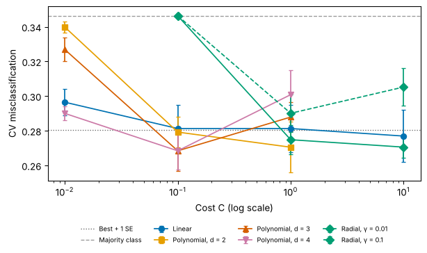

Mean 5-fold CV misclassification rate (bars: plus or minus 1 SE) against cost C for each kernel. The dotted line is the one-SE threshold above the best candidate; the dashed line is the error of always predicting no CHD.

```python
best = cv.loc[cv["CV error"].idxmin()]
threshold = best["CV error"] + best["SE"]
fig, ax = plt.subplots(figsize=(6.5, 4))
styles = {"Linear": ("#0072B2", "o"), "Polynomial, d = 2": ("#E69F00", "s"),
          "Polynomial, d = 3": ("#D55E00", "^"), "Polynomial, d = 4": ("#CC79A7", "v")}
for name, (col, mk) in styles.items():
    sub = cv[cv["Kernel"] == name]
    ax.errorbar(sub["C"], sub["CV error"], yerr=sub["SE"], color=col, marker=mk,
                capsize=2, lw=1.3, label=name)
for g, ls in [(0.01, "-"), (0.1, "--")]:
    sub = cv[(cv["Kernel"] == "Radial") & (cv["gamma"] == g)]
    ax.errorbar(sub["C"], sub["CV error"], yerr=sub["SE"], color="#009E73", marker="D",
                ls=ls, capsize=2, lw=1.3, label=f"Radial, γ = {g}")
ax.axhline(threshold, color="0.4", ls=":", lw=1, label="Best + 1 SE")
ax.axhline(np.mean(y == 1), color="0.6", ls="--", lw=1, label="Majority class")
ax.set_xscale("log")
ax.set(xlabel="Cost C (log scale)", ylabel="CV misclassification")
ax.legend(fontsize=7, ncol=4, frameon=False, loc="upper center", bbox_to_anchor=(0.5, -0.22))
plt.tight_layout()
plt.show()
```

**Preferred model: the linear kernel with $C=10$** (CV error 0.277, SE 0.015).

- **The kernels barely differ.** The lowest CV error is 0.268, from the cubic and quartic polynomial kernels at $C=0.1$, with SE about 0.012. Every kernel has at least one setting within one SE of that minimum (below 0.280): linear at $C=10$, quadratic at $C=1$ (0.271), and radial at $C=1$ and $C=10$ with $\gamma=0.01$ (0.275 and 0.271). With differences of about one percentage point and SEs over one point, five folds cannot rank these kernels.
- **So I chose the simplest one.** Among those within one SE, the linear kernel is the least flexible, has only $C$ to tune, and gives directly interpretable coefficients. It also fits what we saw in Homework 7, where LDA, another linear rule, matched or beat the more flexible QDA on these data.
- **The value of $C$ matters little for the linear kernel.** Errors for $C$ from 0.1 to 10 are all 0.277 to 0.281. $C=10$ is the one setting in that range under the one-SE threshold.
- **The flexible kernels trend the same way.** They do best with small $C$ or small $\gamma$, which are their smoothest settings, and lose accuracy as they are allowed to bend more (polynomial $C=1$ for $d=3,4$, and radial $\gamma=0.1$). This also points to a nearly linear boundary.
- **Over-regularized settings are no better than guessing.** Radial with $C=0.1$ predicts the majority class for everyone (0.346, the share with CHD), and polynomial with $C=0.01$ is close to it.
- **Caveat.** These are CV estimates from one set of five folds. The ranking among the top candidates could change with different folds.

## Question 2: Write and use a short SVM analysis skill

In Homework 8, you reviewed another student’s skill. Review the comments and suggestions you received on your own Homework 7 skill. Use what you learned from both sides of the peer review to write a new, shorter skill for SVM model fitting.

**Write the skill by hand.** Create a `SKILL.md` with a short name and description in YAML frontmatter. Write the entire file yourself, without asking AI to draft or edit it. The instruction body after the closing `---` of the frontmatter must be **no more than 50 lines**, including blank lines. Keep the skill independent of any particular dataset, variable names, or observed results, and load it only when you explicitly invoke it.

Your skill should direct the agent to:

1. judge whether the data are suitable for an SVM analysis;
2. choose which kernels to consider and explain why;
3. identify tuning parameters and a method for tuning them;
4. choose an evaluation method that supports selecting a final model;
5. require a compact figure and table that justify the choices;
6. interpret the fit and report the key numerical results; and
7. prioritize the evidence needed to justify the final model in **no more than one printed page at 11-point font**.

**Apply the skill.** Explicitly invoke your skill to analyze `saheart.csv`, using the same response, nine predictors, and `famhist` coding as in Question 1. Provide these data details when invoking the skill, not in the skill itself. Let the skill guide the analysis, then check the resulting report and calculations.

**Submit the results.** Include the one-page, 11-point analysis report in your Homework 09 submission and append the complete contents of your `SKILL.md` afterward. The appended skill is outside the one-page limit.

**Answer 2.** The skill is saved at `skills/svm-report/SKILL.md`, with `disable-model-invocation: true` so it only loads when invoked explicitly. Its body is 37 lines. In writing it, I used both sides of the peer review:

- **Feedback I received on Homework 7:** state exactly which SE defines the one-SE threshold, make the class of interest a required input, and say how missing predictors are handled.
- **Lessons from the skill I reviewed:** use a selection rule that respects fold noise, report fitted results a reader can interpret, accept inputs from the user’s message, define the output files, and check that the report fits on one page.

I applied the skill with this prompt, giving only the data details:

> Follow the skill in `homework/week-09/skills/svm-report/SKILL.md`. Data: `homework/week-09/data/saheart.csv`. Response: `chd`; class of interest: `chd = 1`. Predictors: the other nine columns, with `famhist` coded 1 = Absent and 2 = Present.

The analysis script and outputs are in `skill-run/` (`svm_analysis.py`, `cv_results.csv`, `svm_cv.png`). I checked every number in the report against the script’s printed output.

### SAheart SVM analysis report

**Setup.** SAheart has n = 462, nine predictors, and `chd = 1` (34.6%) as the class of interest. There are no missing values and n ≥ 10p, so the data suit an SVM after standardizing. With seed 432, I reserved a stratified 25% test set (116 people) and compared 20 settings on the same stratified 10-fold split of the 346 training rows, refitting the scaler in each fold. Linear is the baseline; polynomial (d = 2, 3; offset 1, γ = 1/9) and radial kernels test whether curvature helps.

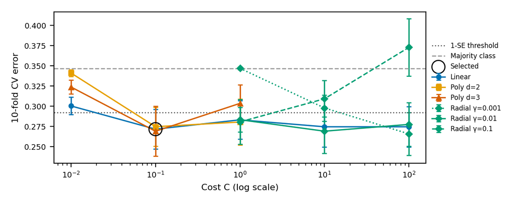

10-fold CV error (±1 SE) by cost C; dotted line = one-SE threshold, ring = selected model.

| Kernel (best setting) | C | γ | CV error | SE |
| --- | --- | --- | --- | --- |
| **Linear (selected)** | **0.1** |  | **0.272** | **0.025** |
| Polynomial, d = 2 | 0.1 | 1/9 | 0.275 | 0.024 |
| Polynomial, d = 3 | 0.1 | 1/9 | 0.269 | 0.031 |
| Radial (lowest CV error) | 100 | 0.001 | 0.266 | 0.026 |

**Selected model and test result.** The lowest CV error is 0.266 (radial, SE 0.026), so the one-SE threshold is 0.292. Twelve of the 20 settings fall below it, and the rule’s simplicity order picks the **linear kernel with C = 0.1**. Refit on all training rows, it has a **test error of 0.259** (30 of 116; 95% Wilson interval 0.188 to 0.345), against 0.345 for always predicting no CHD. The confusion matrix (rows observed, columns predicted) is [65, 11; 19, 21], giving sensitivity 0.525 and specificity 0.855. 216 of the 346 training rows are support vectors (108 per class). The largest standardized coefficients are `famhist` 0.44, age 0.43, `typea` 0.39, tobacco 0.34, and LDL 0.32, all positive. Adiposity, obesity, and alcohol are near 0.

**Findings.** No kernel beats the linear one by more than one SE. The largest gap is 0.006, against SEs of 0.025 to 0.031. The nonlinear kernels do best at their smoothest settings and get worse as they bend more (radial γ = 0.1, C = 100: 0.373), which points to a nearly linear boundary. With 62% of training rows as support vectors, the classes overlap heavily, which fits with every well-tuned kernel landing near 27% CV error.

**Limitations.** One split, with a test interval about 16 points wide. SVM scores are not calibrated probabilities, and the default cutoff misses about half of CHD cases. Adiposity and obesity are correlated (r = 0.72), so their coefficients are unstable.

### Appended `SKILL.md`

```markdown
---
name: svm-report
description: Fit, tune, and report an SVM classifier on a user-supplied dataset. Use only when the user explicitly invokes svm-report by name.
disable-model-invocation: true
---

# SVM analysis report

Inputs (from the user's message): data file, response, predictors and their coding, the class of interest, and a seed (default 432). Ask once if any are missing.

## 1. Check suitability
- Report n, p, class counts, and missing values. Stop and ask if predictors are missing; never impute outside the CV folds.
- SVMs need numeric predictors on comparable scales: standardize inside each fitting fold only.
- Flag a minority class under 10% or n < 10p, and note that SVM gives scores, not calibrated probabilities.

## 2. Kernels
- Always fit a linear kernel as the baseline.
- Add radial and polynomial (degree 2 and 3, offset 1, gamma = 1/p) kernels only to test for curvature. State why each is included.

## 3. Tuning
- Tune C for every kernel on a log grid (e.g., 0.01 to 100); tune gamma for the radial kernel (e.g., 0.001 to 1).
- Keep the grid to about 20 settings total and list every setting held fixed.

## 4. Evaluation and selection
- Reserve a stratified 25% test set first. Build stratified 5- or 10-fold CV on the training set and reuse the same folds for every candidate.
- Score by misclassification rate: mean and SE = fold SD / sqrt(K).
- One-SE rule: threshold = minimum mean CV error + the SE of that minimum-error candidate. Among candidates at or below it, choose linear, then polynomial (lower degree), then radial; within a kernel, choose the smallest C (and smallest gamma).
- Refit the choice on all training data and evaluate it once on the test set.

## 5. Figure and table
- One figure (about 6.5 x 2.6 in): CV error +/- 1 SE against C (log scale), one line per kernel setting, with the threshold and majority-class error as reference lines. Colorblind-safe colors.
- One table: the best setting per kernel, with CV error, SE, and settings. Mark the selected model.

## 6. Interpret and report numbers
- Report test error with a 95% Wilson interval, the confusion matrix, sensitivity and specificity for the class of interest, the number of support vectors, and the majority-class baseline.
- For a linear kernel, list the largest standardized coefficients and their signs. For nonlinear kernels, say they are not directly interpretable.
- State whether the gap to the best competitor exceeds one SE.

## 7. One printed page, 11-point font
- Write a self-contained HTML or PDF plus the analysis script. Order: setup (2 sentences), figure, table, selected model and test result, findings (3 sentences), limitations (2 sentences).
- Prioritize the evidence for the final choice; drop anything else first.
- Print to Letter at 11 pt and shorten until it fits on one page. Every number must match printed output.
```